# Q2.2: How Age and diabetes affect the risk factors related to diabetes ?

Yaëlle Pihan, Marco Carega

13/04/2022

### Table of contents

Setting up data and libraries  
1. How does age affect the risk factors associated with diabetes?  
2. Which of the risk factors are related with diabetes outcome?  
3. Two-Way Anova test considering “Blood Pressure”.  
4. Analyze the distribution of Insulin variable.

## Setting up data and libraries

```r
library(car)
library(carData)
library(sandwich)
library(lmtest)
library(RcmdrMisc)
library(agricolae)
diabetes=read.csv("diabetes.csv")

diabetes$AgeCat=factor(ifelse(diabetes$Age<=30,"young",ifelse(diabetes$Age<=50,"middle","old")))
diabetes$OutCat=factor(ifelse(diabetes$Outcome==1,"True","False"))

summary(diabetes)
```

```
##   Pregnancies        Glucose      BloodPressure    SkinThickness
##  Min.   : 0.000   Min.   :  0.0   Min.   :  0.00   Min.   : 0.00
##  1st Qu.: 1.000   1st Qu.: 99.0   1st Qu.: 62.00   1st Qu.: 0.00
##  Median : 3.000   Median :117.0   Median : 72.00   Median :23.00
##  Mean   : 3.845   Mean   :120.9   Mean   : 69.11   Mean   :20.54
##  3rd Qu.: 6.000   3rd Qu.:140.2   3rd Qu.: 80.00   3rd Qu.:32.00
##  Max.   :17.000   Max.   :199.0   Max.   :122.00   Max.   :99.00
##     Insulin           BMI        DiabetesPedigreeFunction      Age
##  Min.   :  0.0   Min.   : 0.00   Min.   :0.0780           Min.   :21.00
##  1st Qu.:  0.0   1st Qu.:27.30   1st Qu.:0.2437           1st Qu.:24.00
##  Median : 30.5   Median :32.00   Median :0.3725           Median :29.00
##  Mean   : 79.8   Mean   :31.99   Mean   :0.4719           Mean   :33.24
##  3rd Qu.:127.2   3rd Qu.:36.60   3rd Qu.:0.6262           3rd Qu.:41.00
##  Max.   :846.0   Max.   :67.10   Max.   :2.4200           Max.   :81.00
##     Outcome         AgeCat      OutCat
##  Min.   :0.000   middle:270   False:500
##  1st Qu.:0.000   old   : 81   True :268
##  Median :0.000   young :417
##  Mean   :0.349
##  3rd Qu.:1.000
##  Max.   :1.000
```

## 1. How does age affect the risk factors associated with diabetes?

### a. Tests

```
## [1] "----------------------------------------------------------"
## [1] "Pregnancies"
## [1] "----------------------------------------------------------"
## [1] "----------------------Anova test--------------------------"
##              Df Sum Sq Mean Sq F value Pr(>F)
## factor        1   2580    2580   322.5 <2e-16 ***
## Residuals   766   6128       8
## ---
## Signif. codes:  0 '***' 0.001 '**' 0.01 '*' 0.05 '.' 0.1 ' ' 1
## [1] "----------------------Assumption tests--------------------"
##
##  Shapiro-Wilk normality test
##
## data:  residuals(model)
## W = 0.97823, p-value = 2.803e-09
##
##
##  Durbin-Watson test
##
## data:  model
## DW = 1.9592, p-value = 0.5711
## alternative hypothesis: true autocorrelation is not 0
##
##
##  studentized Breusch-Pagan test
##
## data:  model
## BP = 130.82, df = 1, p-value < 2.2e-16
```

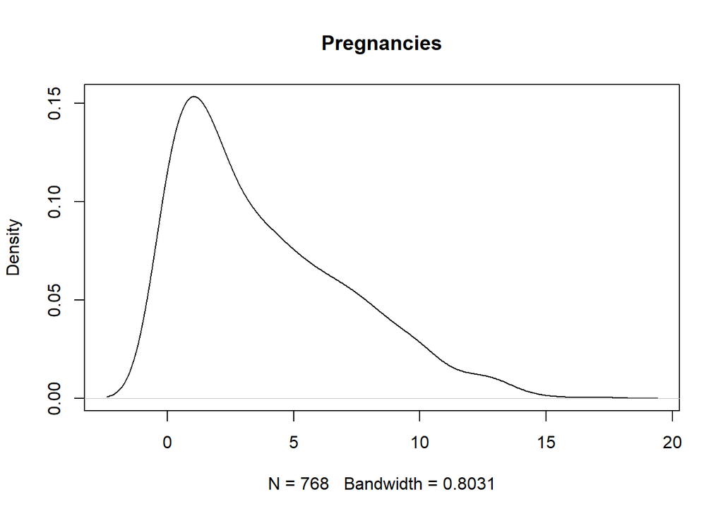

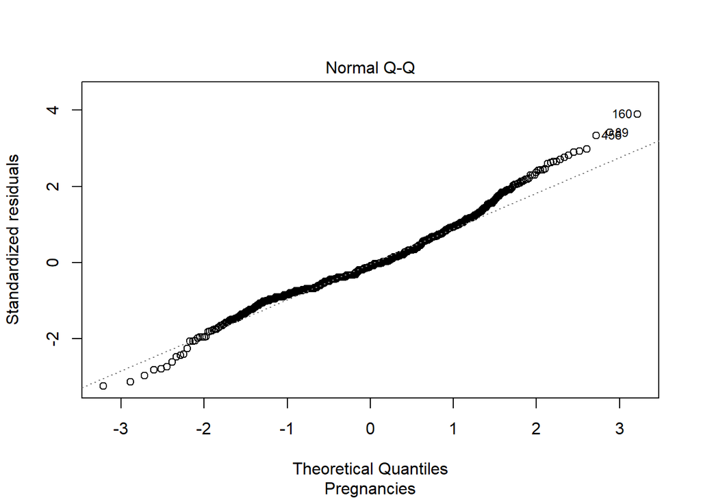

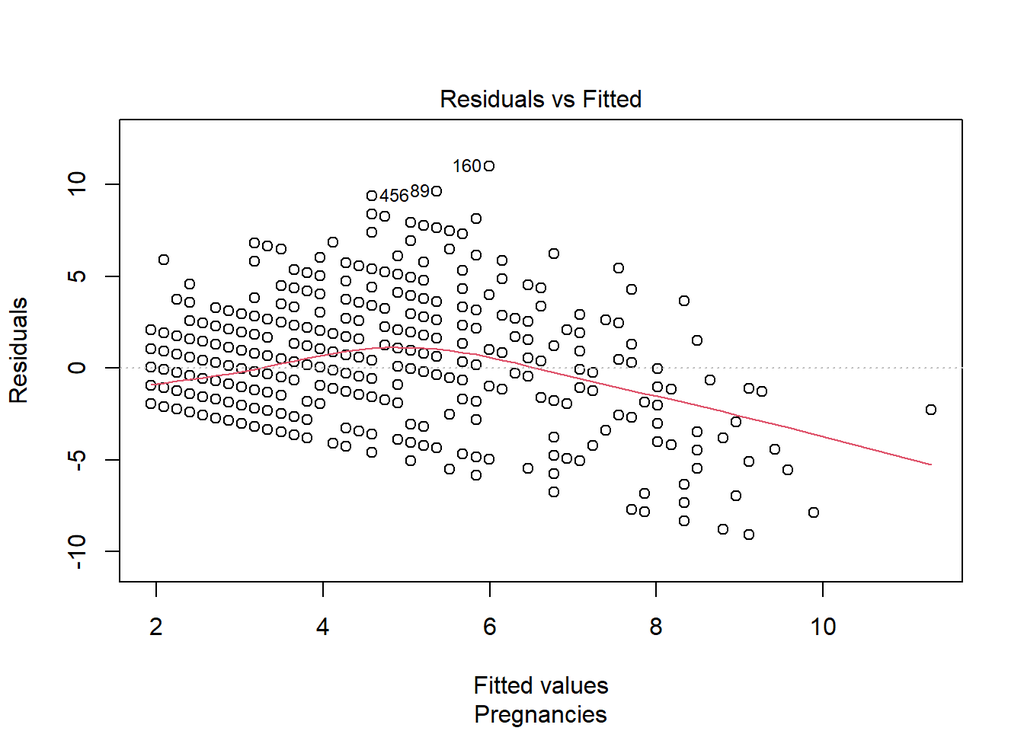

```
## [1] "----------------------------------------------------------"
## [1] "Glucose"
## [1] "----------------------------------------------------------"
## [1] "----------------------Anova test--------------------------"
##              Df Sum Sq Mean Sq F value   Pr(>F)
## factor        1  54445   54445   57.16 1.15e-13 ***
## Residuals   766 729619     953
## ---
## Signif. codes:  0 '***' 0.001 '**' 0.01 '*' 0.05 '.' 0.1 ' ' 1
## [1] "----------------------Assumption tests--------------------"
##
##  Shapiro-Wilk normality test
##
## data:  residuals(model)
## W = 0.97467, p-value = 2.838e-10
##
##
##  Durbin-Watson test
##
## data:  model
## DW = 1.8627, p-value = 0.05678
## alternative hypothesis: true autocorrelation is not 0
##
##
##  studentized Breusch-Pagan test
##
## data:  model
## BP = 2.4585, df = 1, p-value = 0.1169
```

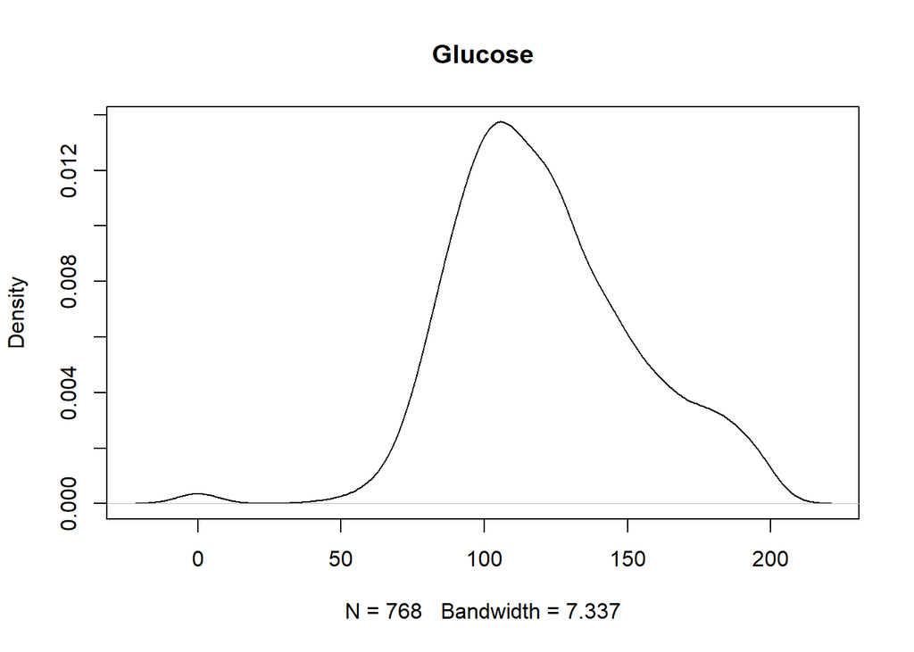

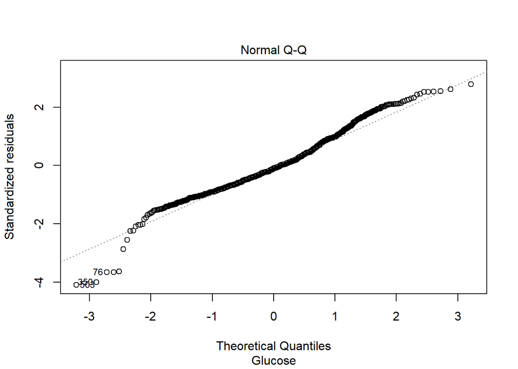

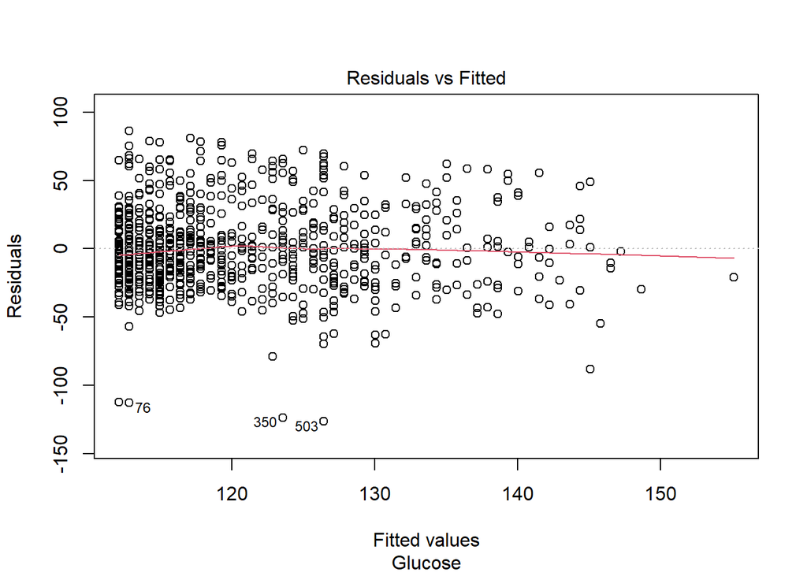

```
## [1] "----------------------------------------------------------"
## [1] "BloodPressure"
## [1] "----------------------------------------------------------"
## [1] "----------------------Anova test--------------------------"
##              Df Sum Sq Mean Sq F value   Pr(>F)
## factor        1  16487   16487   46.62 1.75e-11 ***
## Residuals   766 270868     354
## ---
## Signif. codes:  0 '***' 0.001 '**' 0.01 '*' 0.05 '.' 0.1 ' ' 1
## [1] "----------------------Assumption tests--------------------"
##
##  Shapiro-Wilk normality test
##
## data:  residuals(model)
## W = 0.80752, p-value < 2.2e-16
##
##
##  Durbin-Watson test
##
## data:  model
## DW = 1.9682, p-value = 0.6596
## alternative hypothesis: true autocorrelation is not 0
##
##
##  studentized Breusch-Pagan test
##
## data:  model
## BP = 0.68014, df = 1, p-value = 0.4095
```

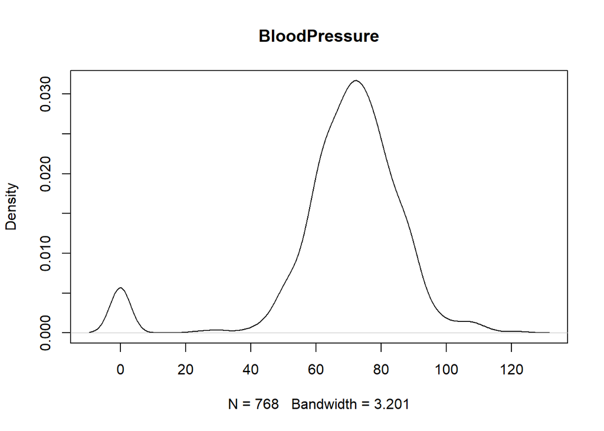

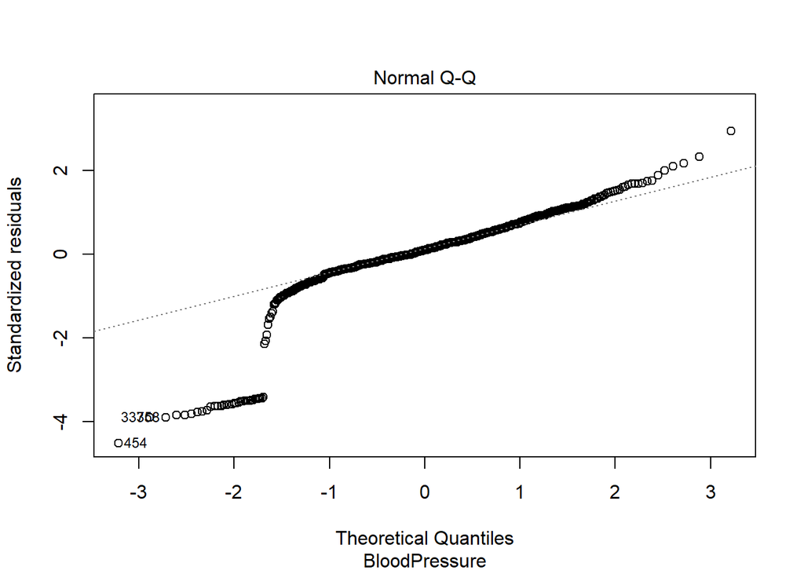

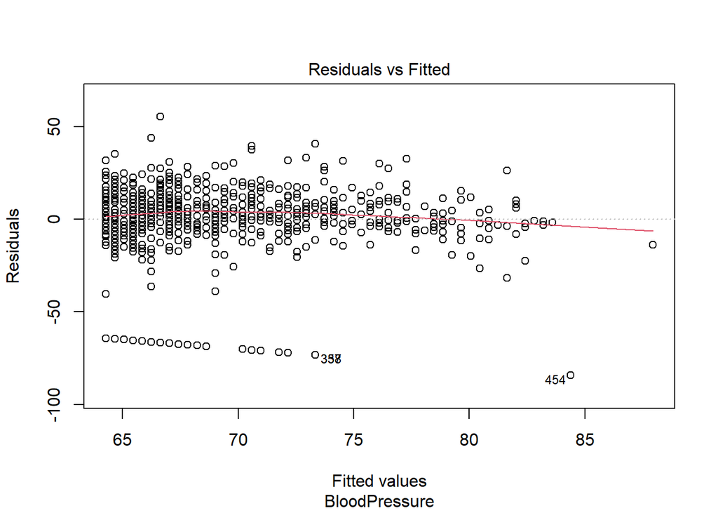

```
## [1] "----------------------------------------------------------"
## [1] "SkinThickness"
## [1] "----------------------------------------------------------"
## [1] "----------------------Anova test--------------------------"
##              Df Sum Sq Mean Sq F value  Pr(>F)
## factor        1   2535  2535.2   10.08 0.00156 **
## Residuals   766 192646   251.5
## ---
## Signif. codes:  0 '***' 0.001 '**' 0.01 '*' 0.05 '.' 0.1 ' ' 1
## [1] "----------------------Assumption tests--------------------"
##
##  Shapiro-Wilk normality test
##
## data:  residuals(model)
## W = 0.93259, p-value < 2.2e-16
##
##
##  Durbin-Watson test
##
## data:  model
## DW = 1.9645, p-value = 0.622
## alternative hypothesis: true autocorrelation is not 0
##
##
##  studentized Breusch-Pagan test
##
## data:  model
## BP = 14.609, df = 1, p-value = 0.0001323
```

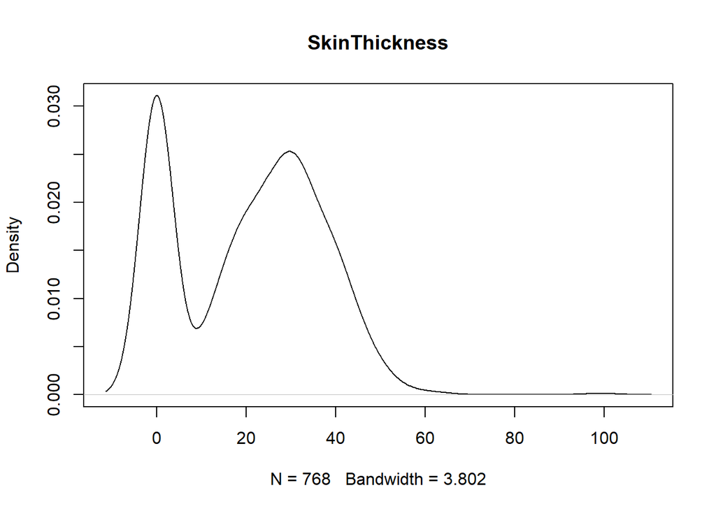

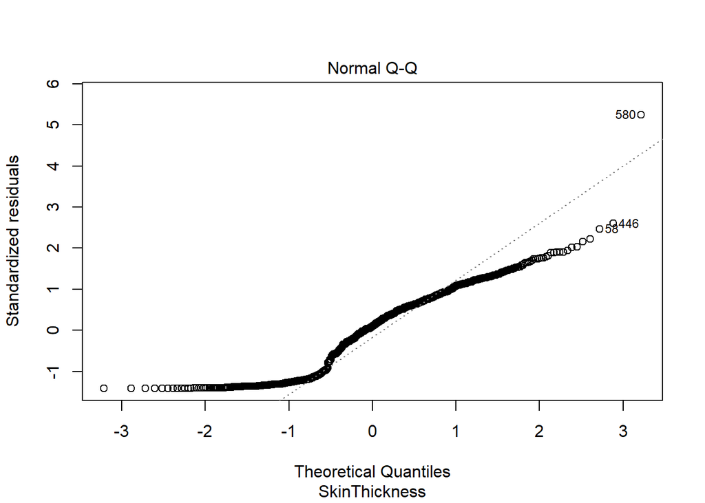

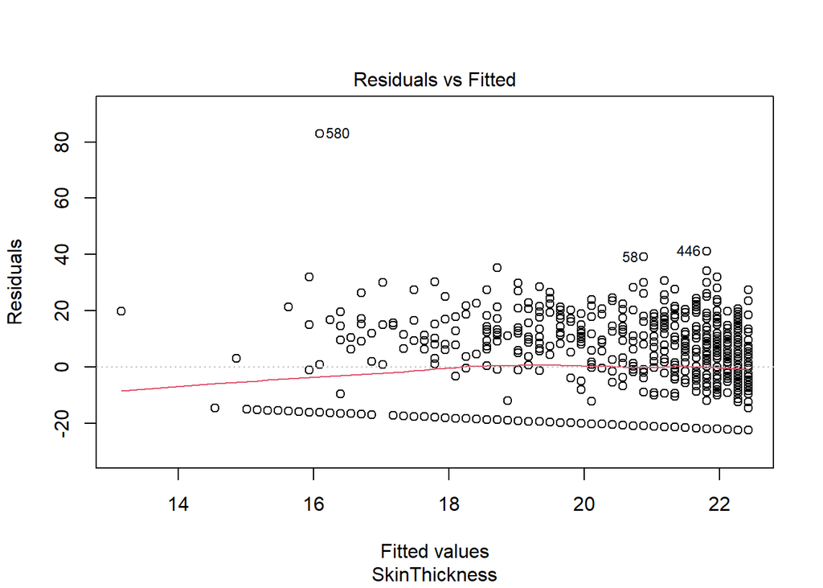

```
## [1] "----------------------------------------------------------"
## [1] "Insulin"
## [1] "----------------------------------------------------------"
## [1] "----------------------Anova test--------------------------"
##              Df   Sum Sq Mean Sq F value Pr(>F)
## factor        1    18109   18109   1.364  0.243
## Residuals   766 10168556   13275
## [1] "----------------------Assumption tests--------------------"
##
##  Shapiro-Wilk normality test
##
## data:  residuals(model)
## W = 0.73572, p-value < 2.2e-16
##
##
##  Durbin-Watson test
##
## data:  model
## DW = 2.0032, p-value = 0.9644
## alternative hypothesis: true autocorrelation is not 0
##
##
##  studentized Breusch-Pagan test
##
## data:  model
## BP = 2.3447, df = 1, p-value = 0.1257
```

[8 more figures not shown]

```r
tests=function(factor){
    for (i in 1:7){
    print("----------------------------------------------------------")
    print(colnames(diabetes)[i])
    print("----------------------------------------------------------")
    print("----------------------Anova test--------------------------")
    model = aov(diabetes[,i]~factor,data=diabetes)
    print(summary(model))
    print("----------------------Assumption tests--------------------")
    print(shapiro.test(residuals(model))) #normality
    print(dwtest(model,alternative = "two.sided")) #independence
    print(bptest(model)) #homoscedasticity
    plot(density(diabetes[,i]), main = colnames(diabetes)[i]) #density plot to identify normality
    plot(model,2,sub = colnames(diabetes)[i]) #QQ plot to test normality
    plot(model,1,sub = colnames(diabetes)[i]) #Residuals vs fitted plot to test homoscedasticity
  }
}

tests(diabetes$Age)
```

### b. Analysis

After analyzing the p_value of each Anova test, we conclude that the age of a patient affects significantly (with a p_value < 0.05) the risk factors below:

- Pregnancies
- Glucose
- Blood pressure
- Skin thickness

On the contrary (p_vale > 0.05), it does not impact:

- Insulin
- BMI
- Diabetes pedigree function

However, we need to be careful about some results because some Anova assumptions are more or less verified depending on the diabetes risk factor considered.

Indeed, by opposition with the first part of Q2, the data we use is real and its groups do not necessary respect normality, independence or homoscedasticity.

In our case, independence test is always verified: p_value > 0,05 and DW in [1.5;2.5], meaning the residuals are not linearly auto-correlated, so independence of the observations is verified.

Therefore, we plot the residuals with a QQ plot showing us how much the residuals follow a linear regression. If we can identify easily a portion of straight line, we accept normality assumption. As for homoscedasticity, the residuals vs Fitted plot is supposed to show us equally spread residuals around the horizontal line.

As a consequence, Anova results for Pregnancies, Insulin, Skin thickness and Diabetes pedigree function should be reconsidered and some transformations could be done on these dependent variables to try to make them fit Anova model.

## 2. Which of the risk factors are related with diabetes outcome?

### a. Tests

```r
tests(diabetes$Outcome)
```

```
## [1] "----------------------------------------------------------"
## [1] "Pregnancies"
## [1] "----------------------------------------------------------"
## [1] "----------------------Anova test--------------------------"
##              Df Sum Sq Mean Sq F value   Pr(>F)
## factor        1    429   428.8   39.67 5.07e-10 ***
## Residuals   766   8280    10.8
## ---
## Signif. codes:  0 '***' 0.001 '**' 0.01 '*' 0.05 '.' 0.1 ' ' 1
## [1] "----------------------Assumption tests--------------------"
##
##  Shapiro-Wilk normality test
##
## data:  residuals(model)
## W = 0.9389, p-value < 2.2e-16
##
##
##  Durbin-Watson test
##
## data:  model
## DW = 1.9227, p-value = 0.2832
## alternative hypothesis: true autocorrelation is not 0
##
##
##  studentized Breusch-Pagan test
##
## data:  model
## BP = 16.25, df = 1, p-value = 5.55e-05
```

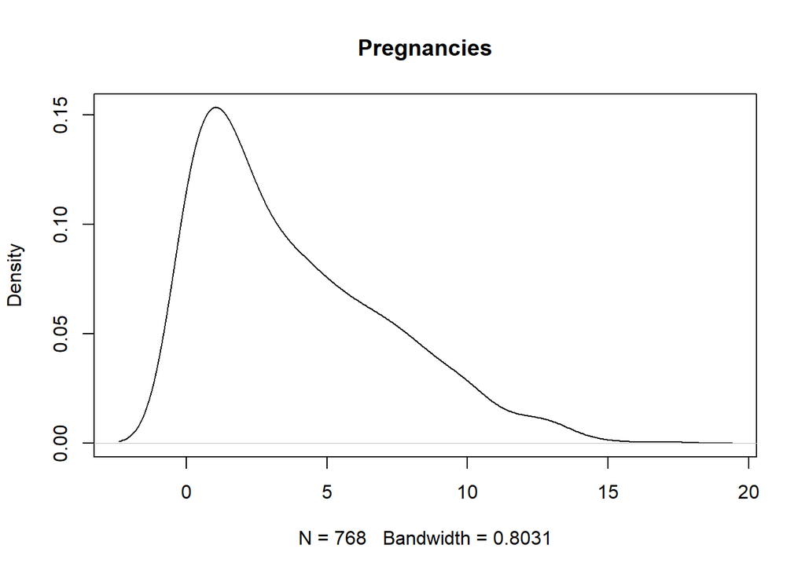

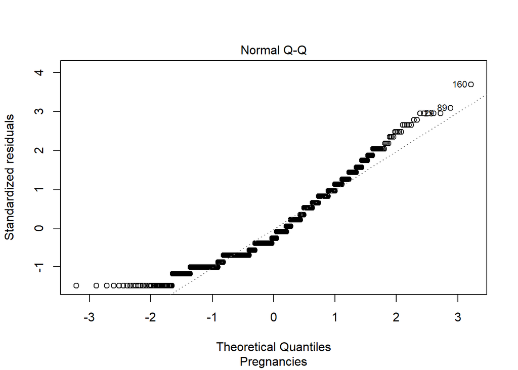

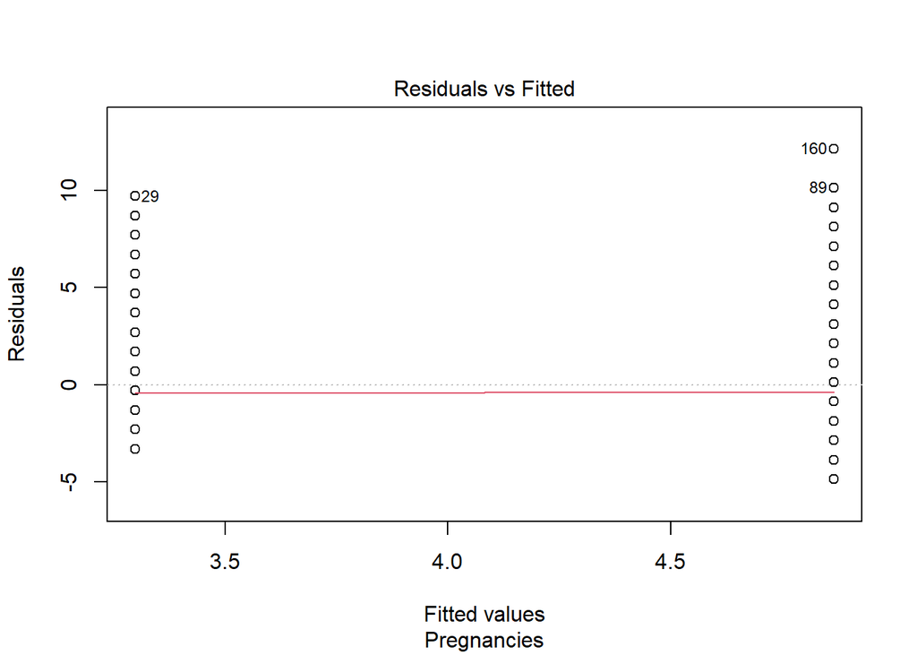

```
## [1] "----------------------------------------------------------"
## [1] "Glucose"
## [1] "----------------------------------------------------------"
## [1] "----------------------Anova test--------------------------"
##              Df Sum Sq Mean Sq F value Pr(>F)
## factor        1 170689  170689   213.2 <2e-16 ***
## Residuals   766 613375     801
## ---
## Signif. codes:  0 '***' 0.001 '**' 0.01 '*' 0.05 '.' 0.1 ' ' 1
## [1] "----------------------Assumption tests--------------------"
##
##  Shapiro-Wilk normality test
##
## data:  residuals(model)
## W = 0.97511, p-value = 3.726e-10
##
##
##  Durbin-Watson test
##
## data:  model
## DW = 1.872, p-value = 0.07563
## alternative hypothesis: true autocorrelation is not 0
##
##
##  studentized Breusch-Pagan test
##
## data:  model
## BP = 8.0707, df = 1, p-value = 0.004499
```

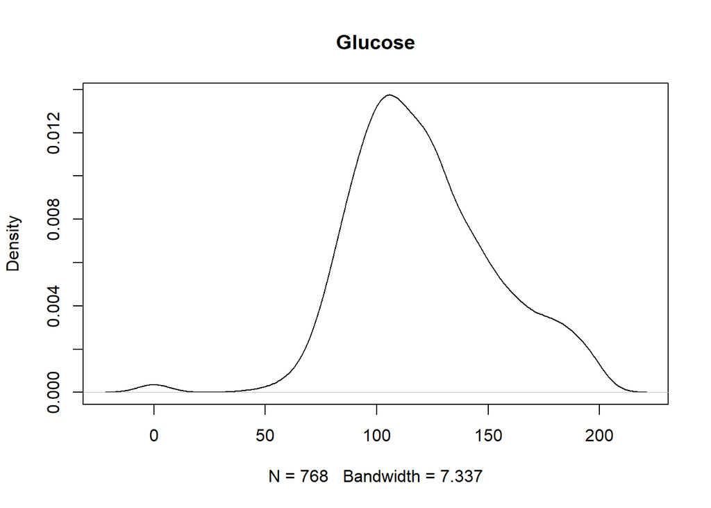

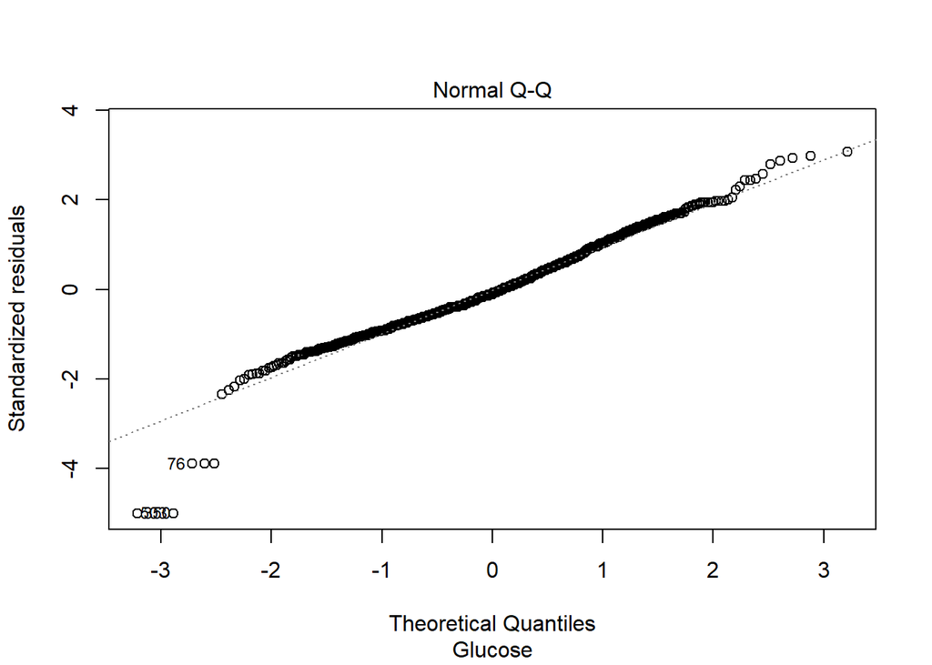

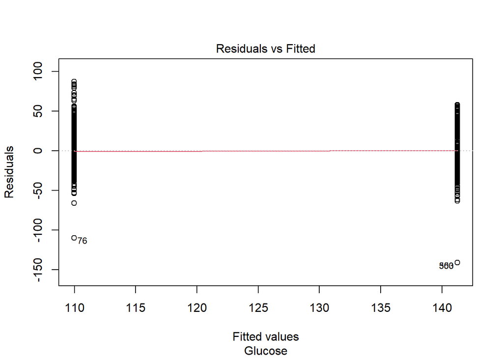

```
## [1] "----------------------------------------------------------"
## [1] "BloodPressure"
## [1] "----------------------------------------------------------"
## [1] "----------------------Anova test--------------------------"
##              Df Sum Sq Mean Sq F value Pr(>F)
## factor        1   1217  1216.6   3.257 0.0715 .
## Residuals   766 286138   373.5
## ---
## Signif. codes:  0 '***' 0.001 '**' 0.01 '*' 0.05 '.' 0.1 ' ' 1
## [1] "----------------------Assumption tests--------------------"
##
##  Shapiro-Wilk normality test
##
## data:  residuals(model)
## W = 0.81468, p-value < 2.2e-16
##
##
##  Durbin-Watson test
##
## data:  model
## DW = 1.9587, p-value = 0.5666
## alternative hypothesis: true autocorrelation is not 0
##
##
##  studentized Breusch-Pagan test
##
## data:  model
## BP = 3.1061, df = 1, p-value = 0.078
```

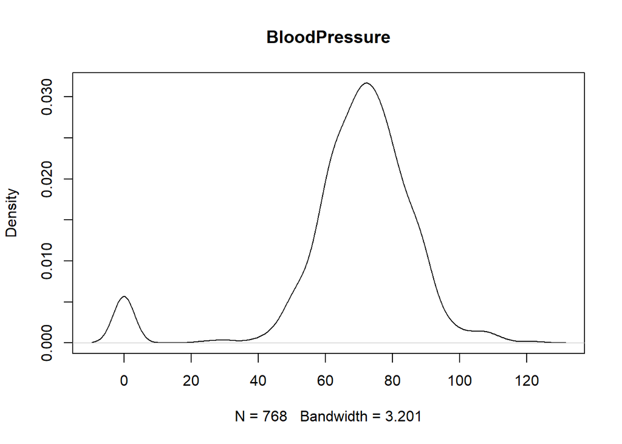

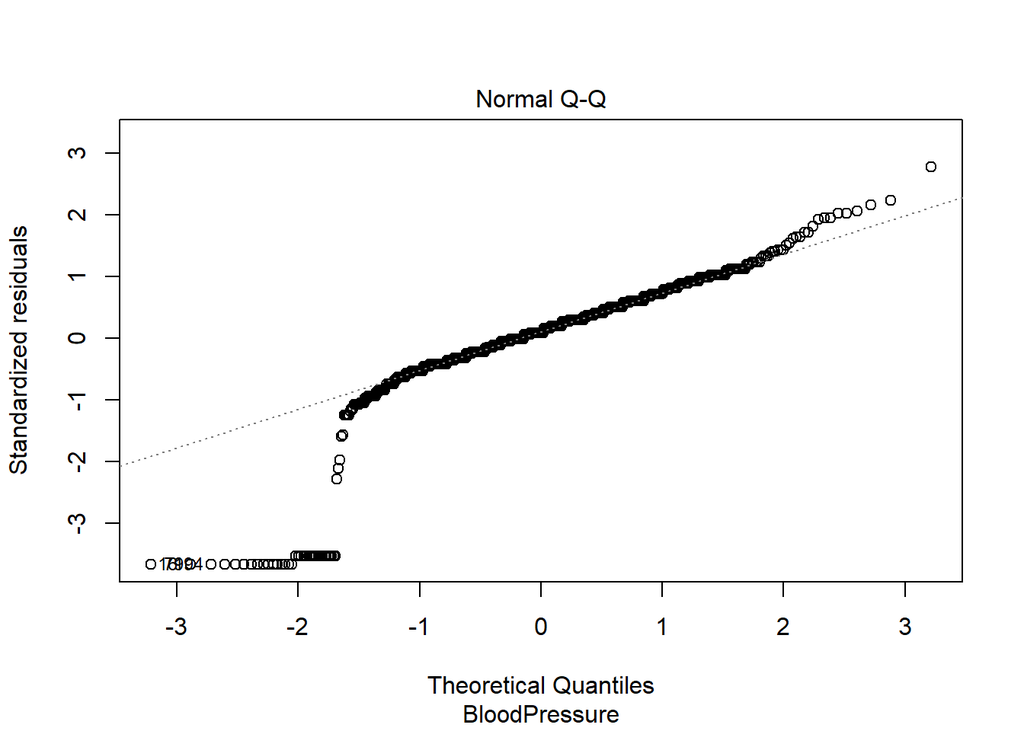

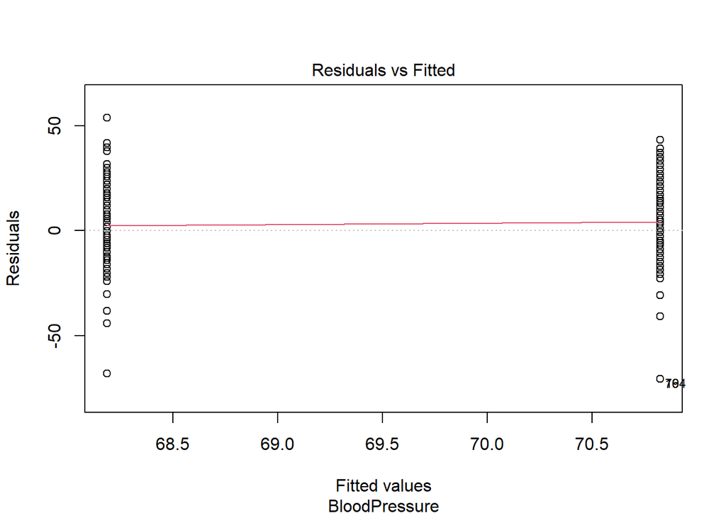

```
## [1] "----------------------------------------------------------"
## [1] "SkinThickness"
## [1] "----------------------------------------------------------"
## [1] "----------------------Anova test--------------------------"
##              Df Sum Sq Mean Sq F value Pr(>F)
## factor        1   1091  1090.7   4.304 0.0383 *
## Residuals   766 194090   253.4
## ---
## Signif. codes:  0 '***' 0.001 '**' 0.01 '*' 0.05 '.' 0.1 ' ' 1
## [1] "----------------------Assumption tests--------------------"
##
##  Shapiro-Wilk normality test
##
## data:  residuals(model)
## W = 0.92004, p-value < 2.2e-16
##
##
##  Durbin-Watson test
##
## data:  model
## DW = 1.9982, p-value = 0.9794
## alternative hypothesis: true autocorrelation is not 0
##
##
##  studentized Breusch-Pagan test
##
## data:  model
## BP = 15.338, df = 1, p-value = 8.987e-05
```

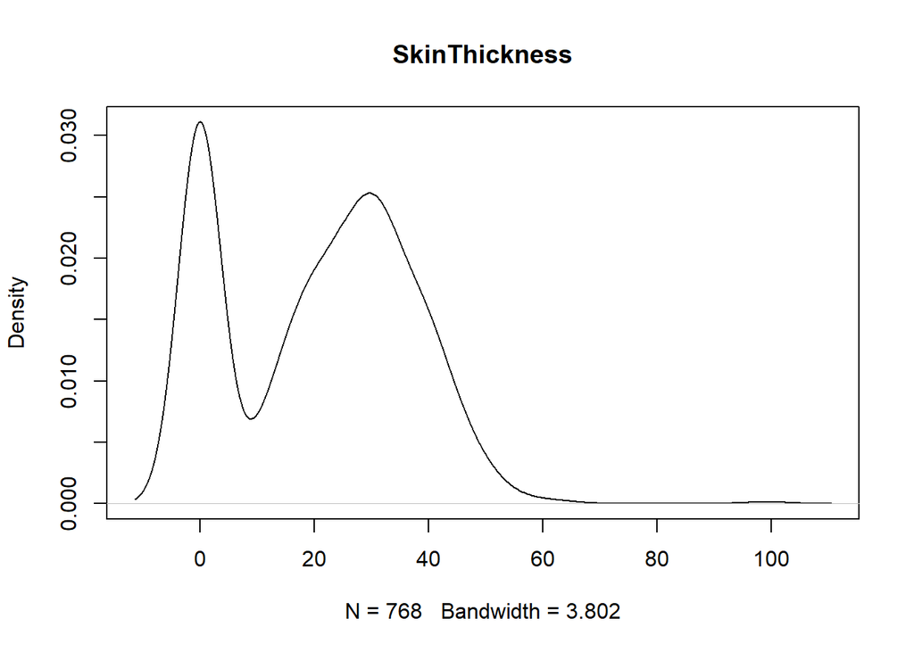

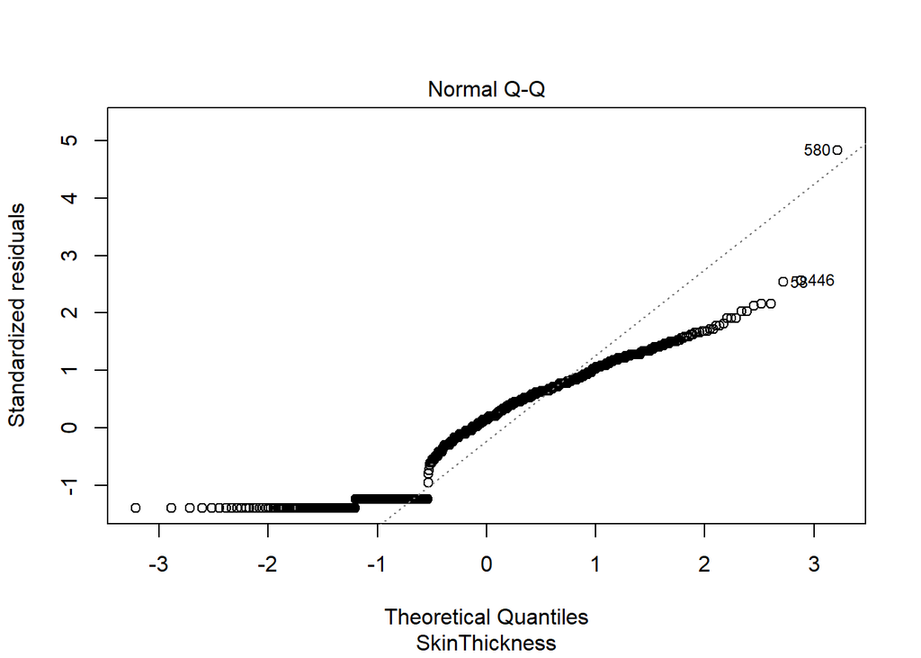

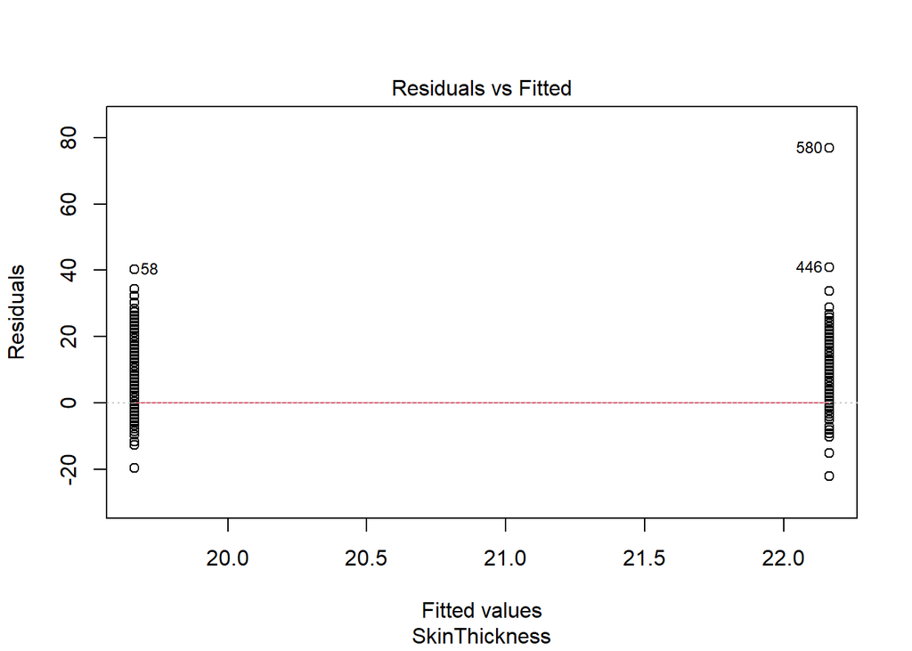

```
## [1] "----------------------------------------------------------"
## [1] "Insulin"
## [1] "----------------------------------------------------------"
## [1] "----------------------Anova test--------------------------"
##              Df   Sum Sq Mean Sq F value   Pr(>F)
## factor        1   173609  173609   13.28 0.000286 ***
## Residuals   766 10013056   13072
## ---
## Signif. codes:  0 '***' 0.001 '**' 0.01 '*' 0.05 '.' 0.1 ' ' 1
## [1] "----------------------Assumption tests--------------------"
##
##  Shapiro-Wilk normality test
##
## data:  residuals(model)
## W = 0.77776, p-value < 2.2e-16
##
##
##  Durbin-Watson test
##
## data:  model
## DW = 2.0357, p-value = 0.6204
## alternative hypothesis: true autocorrelation is not 0
##
##
##  studentized Breusch-Pagan test
##
## data:  model
## BP = 10.126, df = 1, p-value = 0.001462
```

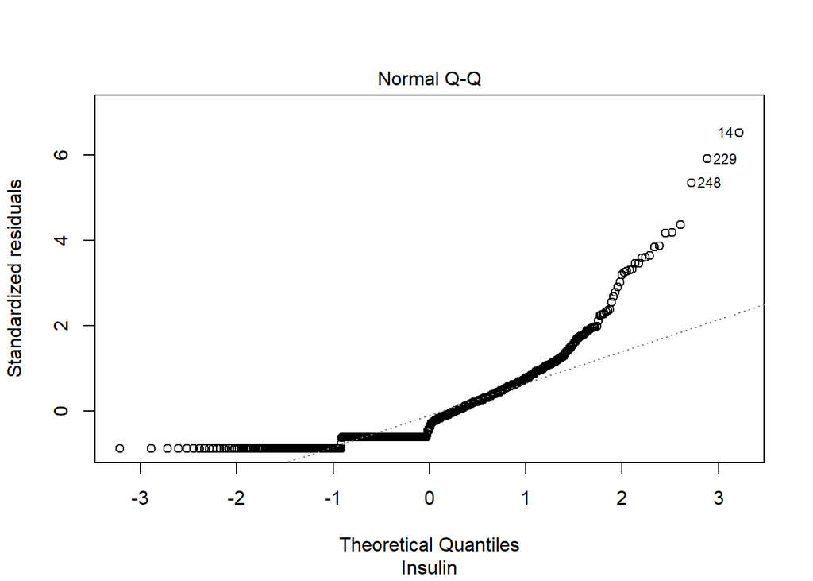

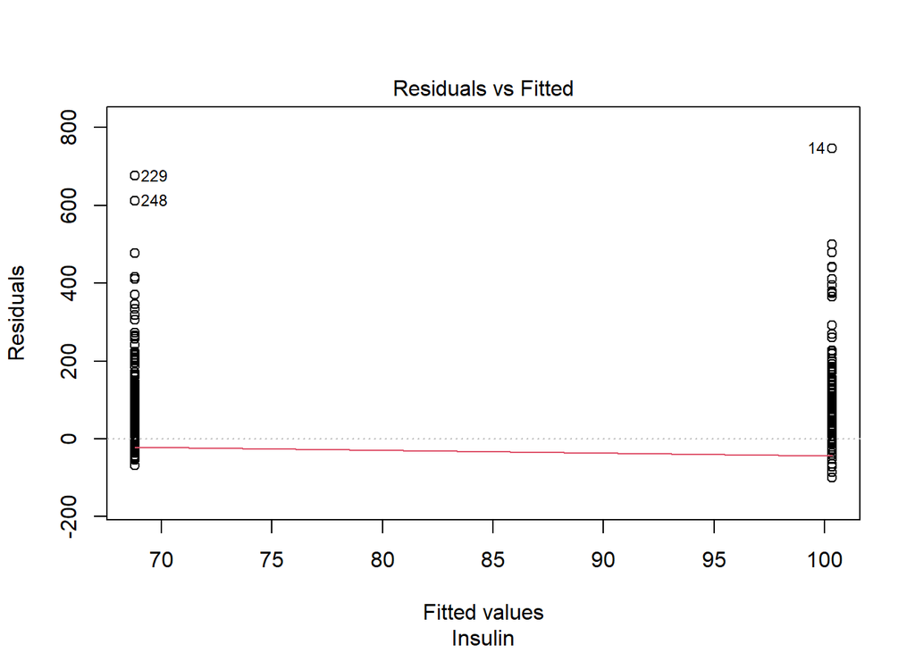

```
## [1] "----------------------------------------------------------"
## [1] "BMI"
## [1] "----------------------------------------------------------"
## [1] "----------------------Anova test--------------------------"
##              Df Sum Sq Mean Sq F value Pr(>F)
## factor        1   4084    4084   71.77 <2e-16 ***
## Residuals   766  43592      57
## ---
## Signif. codes:  0 '***' 0.001 '**' 0.01 '*' 0.05 '.' 0.1 ' ' 1
## [1] "----------------------Assumption tests--------------------"
##
##  Shapiro-Wilk normality test
##
## data:  residuals(model)
## W = 0.94359, p-value < 2.2e-16
##
##
##  Durbin-Watson test
##
## data:  model
## DW = 1.9646, p-value = 0.6228
## alternative hypothesis: true autocorrelation is not 0
##
##
##  studentized Breusch-Pagan test
##
## data:  model
## BP = 0.4094, df = 1, p-value = 0.5223
```

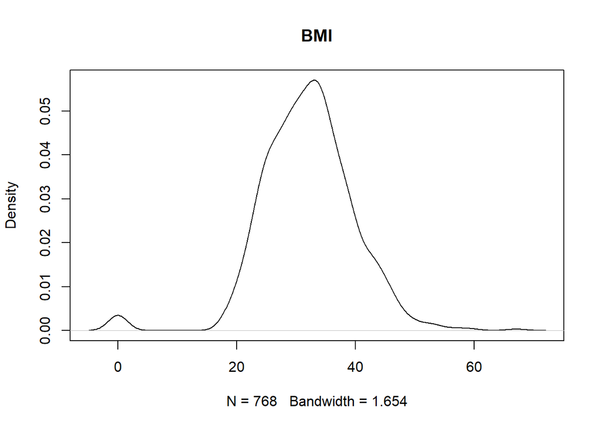

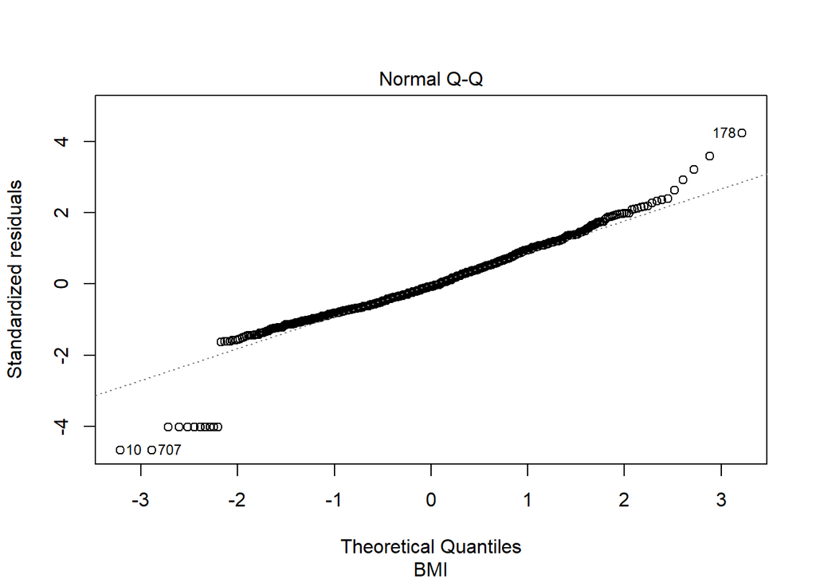

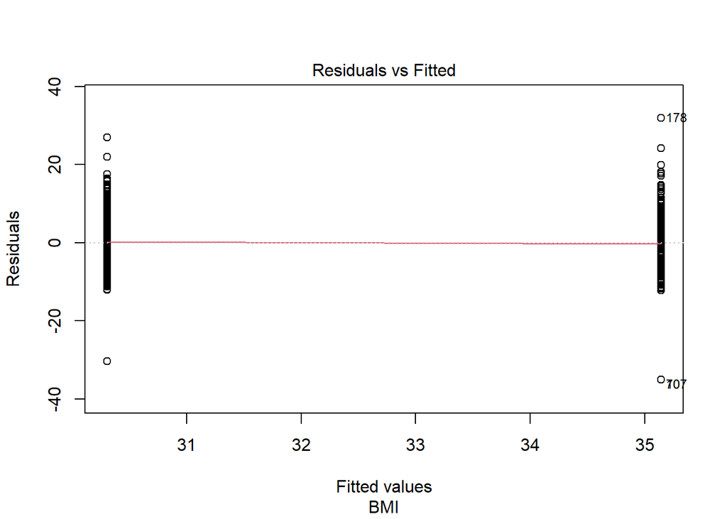

```
## [1] "----------------------------------------------------------"
## [1] "DiabetesPedigreeFunction"
## [1] "----------------------------------------------------------"
## [1] "----------------------Anova test--------------------------"
##              Df Sum Sq Mean Sq F value   Pr(>F)
## factor        1   2.54  2.5447   23.87 1.25e-06 ***
## Residuals   766  81.66  0.1066
## ---
## Signif. codes:  0 '***' 0.001 '**' 0.01 '*' 0.05 '.' 0.1 ' ' 1
## [1] "----------------------Assumption tests--------------------"
##
##  Shapiro-Wilk normality test
##
## data:  residuals(model)
## W = 0.84939, p-value < 2.2e-16
##
##
##  Durbin-Watson test
##
## data:  model
## DW = 1.9879, p-value = 0.8666
## alternative hypothesis: true autocorrelation is not 0
##
##
##  studentized Breusch-Pagan test
##
## data:  model
## BP = 4.885, df = 1, p-value = 0.02709
```

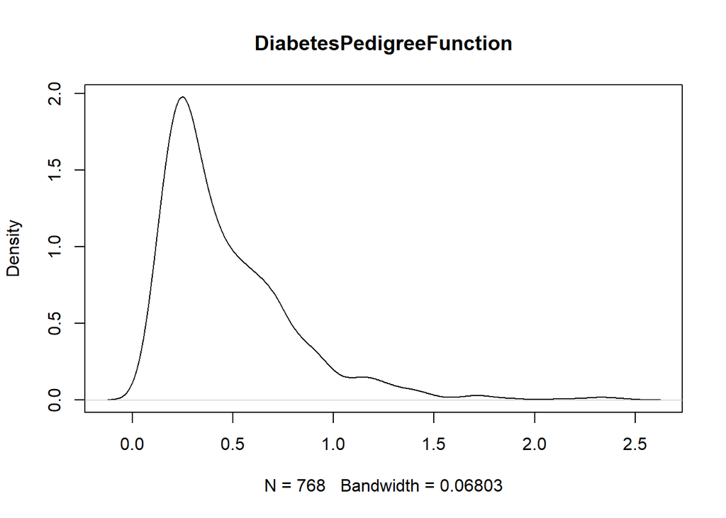

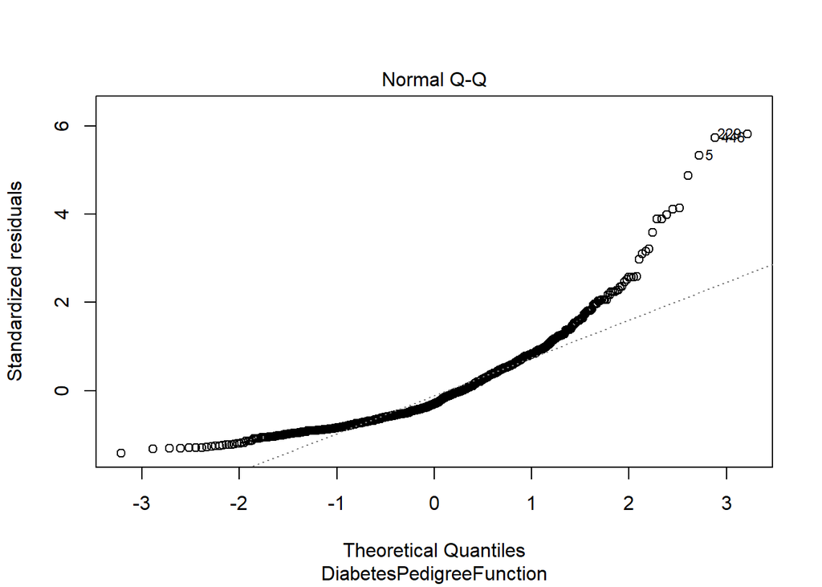

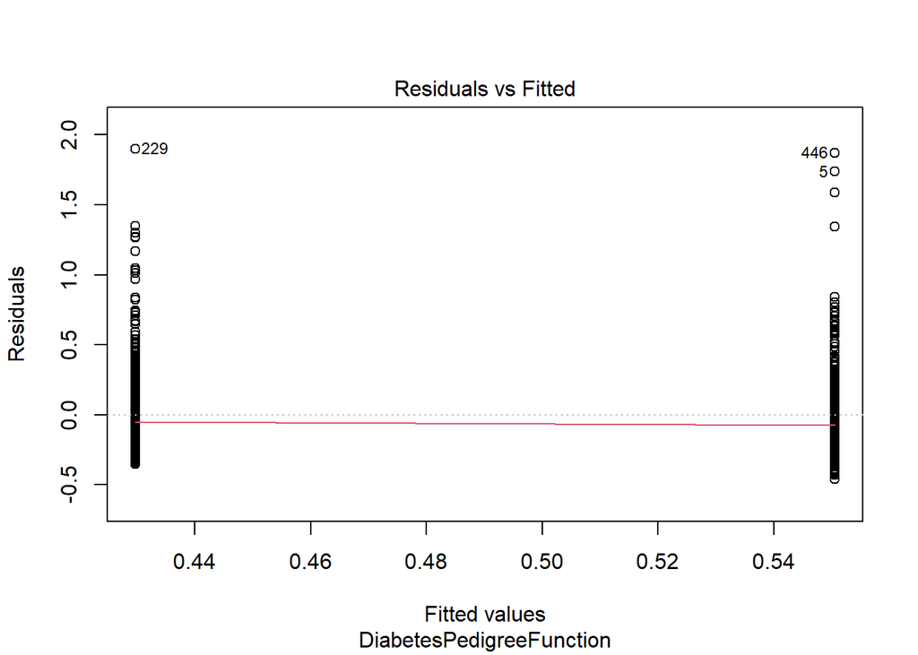

### b. Analysis

After analyzing the p_value of each Anova test, we conclude that the risk factors below are related significantly with diabetes outcome (p_value < 0,05):

- Pregnancies
- Glucose
- Skin thickness
- Insulin
- BMI
- Diabetes pedigree function

On the contrary, Blood pressure is not related with diabetes outcome (p_value > 0.05).

Like before, we need to reconsider these results after analyzing if anova assumptions are verified.

About normality, we choose to reject: Pregnancies, Insulin, Skin thickness and Diabetes pedigree function.

### 3.1 Two-Way Anova test considering “Blood Pressure”

Detail the results of Two-Way ANOVA considering “Blood Pressure” as dependent variable, and the age groups and the indicator of diabetes as independent variables.

### a. Anova Two way test

Anova assumptions were tested before.

```r
model2 <- aov(diabetes$BloodPressure~diabetes$AgeCat+diabetes$OutCat, data = diabetes)
summary(model2)
```

```
##                  Df Sum Sq Mean Sq F value   Pr(>F)
## diabetes$AgeCat   2  15459    7730  21.720 6.69e-10 ***
## diabetes$OutCat   1      3       3   0.007    0.931
## Residuals       764 271893     356
## ---
## Signif. codes:  0 '***' 0.001 '**' 0.01 '*' 0.05 '.' 0.1 ' ' 1
```

```r
TukeyHSD((model2))
```

```
##   Tukey multiple comparisons of means
##     95% family-wise confidence level
##
## Fit: aov(formula = diabetes$BloodPressure ~ diabetes$AgeCat + diabetes$OutCat, data = diabetes)
##
## $`diabetes$AgeCat`
##                    diff         lwr       upr     p adj
## old-middle     6.219753   0.6075672 11.831939 0.0255266
## young-middle  -6.839222 -10.2996621 -3.378782 0.0000121
## young-old    -13.058975 -18.4380428 -7.679907 0.0000000
##
## $`diabetes$OutCat`
##                 diff       lwr      upr     p adj
## True-False 0.1175228 -2.686082 2.921128 0.9344384
```

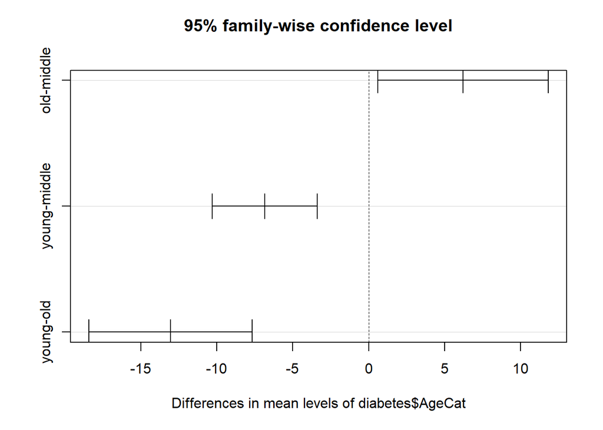

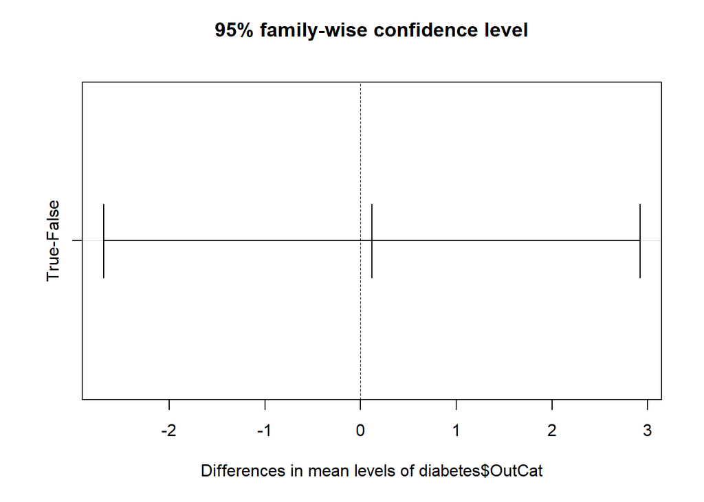

```r
plot(TukeyHSD((model2)))
```

### b. Analysis  
Thanks to Anova test results, we can conclude that the Age group category has a significant impact (*** and p_value<<0.05) on blood pressure whereas it is not the case for the indicator of diabetes (p_value = 0.931 > 0.05).

Moreover, Tukey Posthoc test gives the adjusted values for all possible pairs, and as they are all < 0.05, we can conclude that the difference of means come from all groups and explains anova results: Age groups have a significant impact on blood pressure values.

## 3.2 Analyze the interaction term of two factors.

### a. Interaction graph

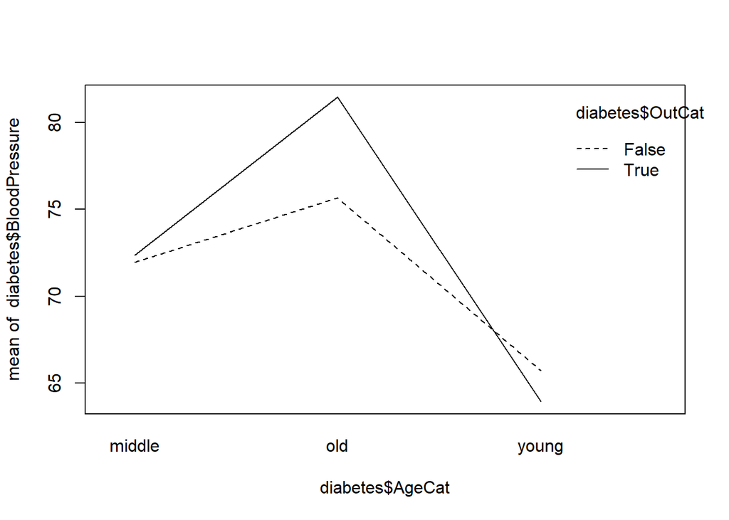

```r
interaction.plot(diabetes$AgeCat,diabetes$OutCat, diabetes$BloodPressure, fun=mean, type="l", legend=TRUE)
```

```r
model2 <- aov(diabetes$BloodPressure~diabetes$AgeCat*diabetes$OutCat, data = diabetes)
summary(model2)
```

```
##                                  Df Sum Sq Mean Sq F value   Pr(>F)
## diabetes$AgeCat                   2  15459    7730  21.735 6.61e-10 ***
## diabetes$OutCat                   1      3       3   0.007    0.931
## diabetes$AgeCat:diabetes$OutCat   2    904     452   1.271    0.281
## Residuals                       762 270988     356
## ---
## Signif. codes:  0 '***' 0.001 '**' 0.01 '*' 0.05 '.' 0.1 ' ' 1
```

### b. Analysis

As we can see, the lines of diabetes indicator intercept, meaning there is likely an interaction effect between the age groups and diabetes indicator. However when we compute Anova with the interaction effect, the interaction is not significant enough (p_value = 0.281 > 0.05).  
## 4.1 Analyze the distribution of Insulin variable.

```r
plot(density(diabetes$Insulin),main="Insulin")
```

[output not shown]

```r
#Boxplot(diabetes$Insulin~diabetes$AgeCat,data=data,id=FALSE)
#Boxplot(diabetes$Insulin~diabetes$OutCat,data=data,id=FALSE)
```

## 4.2 What would you recommend to fit an ANOVA model using Insulin levels as the dependent variable?

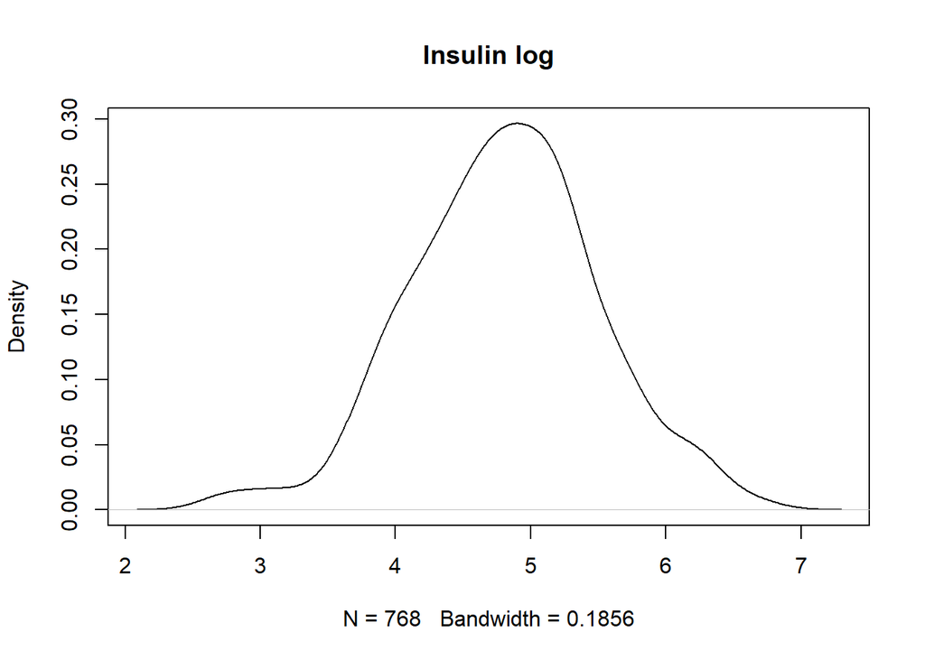

```r
diabetes$Insulin_log<- log(diabetes$Insulin)
plot(density(diabetes$Insulin_log),main="Insulin log")
```

```r
# shapiro.test(diabetes$Insulin_log)
# diabetes["Insulin_log"][diabetes["Insulin_log"] == "-Inf"] <- -10000
# model2 <- aov(diabetes$Insulin_log~diabetes$AgeCat,diabetes)
# summary(model2)
```

In order to make Insulin fit an anova model, we could do a logarithmic transformation.